# Informe mensual de las cotizaciones al Sistema de la Protección Social

# 4 Aspectos metodológicos

## 4.1 Estimación interanual de las cotizaciones (Año tipo 2012 - 2019)

El **Índice Estacional Medio (IEM)** contrasta el número de relaciones laborales de un mes en particular sobre el total observado en enero de dicho año. La UGPP realiza una estimación del indicador con el fin de conocer el comportamiento típico de los cotizantes a lo largo del año y poder identificar cambios atipicos en los aportes.

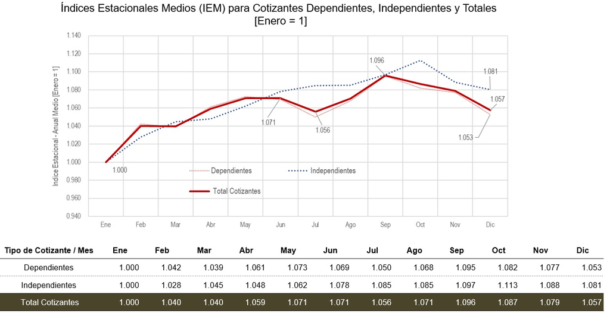

## 4.2 Estimación de los cotizantes en cada enero.

El **IEM** está en función del número de cotizantes de cada mes con el número de cotizante en enero de cada año y nos permite conocer el comportamiento esperado interanualmente. Con el fin de tener una estimación en cada periodo, en un escenario sin afectación por pandemia, se realiza una estimación del número de cotizantes en enero de cada año a partir del 2021 a partir del pronóstico de cotizantes como se muestra en la siguiente grafica.

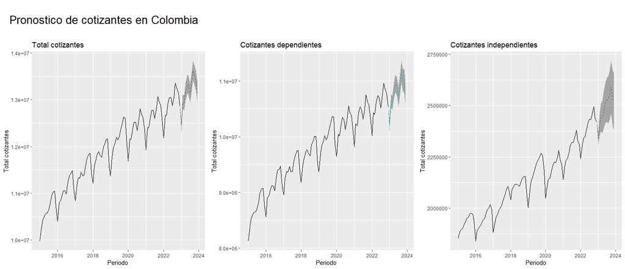

El número esperado de cotizantes en enero 2023, sin la afectación económica, asciende a los 12,4 millones con un crecimiento del 2.2%. El crecimiento anual esperado en los dependientes es del 2.1% y en los independientes del 4.4%.

Total cotizantes estimados de enero en cada año despues de 2021

[output not shown]